# Risk Factor Analysis

## Outcome Variable

**Outcome Variable:** y_rate_wtkg

## Predictor Variables

**Intervention Variable:** vagbrth

**Adjustment Set:**

unadjusted

## Stratifying Variables

The analysis was stratified on these variable(s):

- agecat
- studyid
- country

## Data Summary

| agecat | studyid | country | vagbrth | n_cell | n |
| --- | --- | --- | --- | --- | --- |
| 0-3 months | CMC-V-BCS-2002 | INDIA | 0 | 23 | 331 |
| 0-3 months | CMC-V-BCS-2002 | INDIA | 1 | 308 | 331 |
| 0-3 months | IRC | INDIA | 0 | 66 | 394 |
| 0-3 months | IRC | INDIA | 1 | 328 | 394 |
| 0-3 months | NIH-Crypto | BANGLADESH | 0 | 195 | 472 |
| 0-3 months | NIH-Crypto | BANGLADESH | 1 | 277 | 472 |
| 0-3 months | PROBIT | BELARUS | 0 | 1720 | 15327 |
| 0-3 months | PROBIT | BELARUS | 1 | 13607 | 15327 |
| 0-3 months | PROVIDE | BANGLADESH | 0 | 149 | 640 |
| 0-3 months | PROVIDE | BANGLADESH | 1 | 491 | 640 |
| 0-3 months | TanzaniaChild2 | TANZANIA, UNITED REPUBLIC OF | 0 | 189 | 1997 |
| 0-3 months | TanzaniaChild2 | TANZANIA, UNITED REPUBLIC OF | 1 | 1808 | 1997 |
| 0-3 months | ZVITAMBO | ZIMBABWE | 0 | 704 | 8110 |
| 0-3 months | ZVITAMBO | ZIMBABWE | 1 | 7406 | 8110 |
| 3-6 months | CMC-V-BCS-2002 | INDIA | 0 | 21 | 322 |
| 3-6 months | CMC-V-BCS-2002 | INDIA | 1 | 301 | 322 |
| 3-6 months | IRC | INDIA | 0 | 66 | 399 |
| 3-6 months | IRC | INDIA | 1 | 333 | 399 |
| 3-6 months | NIH-Crypto | BANGLADESH | 0 | 184 | 449 |
| 3-6 months | NIH-Crypto | BANGLADESH | 1 | 265 | 449 |
| 3-6 months | PROBIT | BELARUS | 0 | 1472 | 13317 |
| 3-6 months | PROBIT | BELARUS | 1 | 11845 | 13317 |
| 3-6 months | PROVIDE | BANGLADESH | 0 | 139 | 601 |
| 3-6 months | PROVIDE | BANGLADESH | 1 | 462 | 601 |
| 3-6 months | TanzaniaChild2 | TANZANIA, UNITED REPUBLIC OF | 0 | 158 | 1645 |
| 3-6 months | TanzaniaChild2 | TANZANIA, UNITED REPUBLIC OF | 1 | 1487 | 1645 |
| 3-6 months | ZVITAMBO | ZIMBABWE | 0 | 531 | 6090 |
| 3-6 months | ZVITAMBO | ZIMBABWE | 1 | 5559 | 6090 |
| 6-9 months | CMC-V-BCS-2002 | INDIA | 0 | 22 | 325 |
| 6-9 months | CMC-V-BCS-2002 | INDIA | 1 | 303 | 325 |

[output cut: 80 more lines]

The following strata were considered:

- agecat: 0-3 months, studyid: CMC-V-BCS-2002, country: INDIA
- agecat: 0-3 months, studyid: IRC, country: INDIA
- agecat: 0-3 months, studyid: NIH-Crypto, country: BANGLADESH
- agecat: 0-3 months, studyid: PROBIT, country: BELARUS
- agecat: 0-3 months, studyid: PROVIDE, country: BANGLADESH
- agecat: 0-3 months, studyid: TanzaniaChild2, country: TANZANIA, UNITED REPUBLIC OF
- agecat: 0-3 months, studyid: ZVITAMBO, country: ZIMBABWE
- agecat: 12-15 months, studyid: CMC-V-BCS-2002, country: INDIA
- agecat: 12-15 months, studyid: IRC, country: INDIA
- agecat: 12-15 months, studyid: NIH-Crypto, country: BANGLADESH
- agecat: 12-15 months, studyid: PROBIT, country: BELARUS
- agecat: 12-15 months, studyid: PROVIDE, country: BANGLADESH
- agecat: 12-15 months, studyid: TanzaniaChild2, country: TANZANIA, UNITED REPUBLIC OF
- agecat: 12-15 months, studyid: ZVITAMBO, country: ZIMBABWE
- agecat: 15-18 months, studyid: CMC-V-BCS-2002, country: INDIA
- agecat: 15-18 months, studyid: IRC, country: INDIA
- agecat: 15-18 months, studyid: NIH-Crypto, country: BANGLADESH
- agecat: 15-18 months, studyid: PROBIT, country: BELARUS
- agecat: 15-18 months, studyid: PROVIDE, country: BANGLADESH
- agecat: 15-18 months, studyid: TanzaniaChild2, country: TANZANIA, UNITED REPUBLIC OF
- agecat: 15-18 months, studyid: ZVITAMBO, country: ZIMBABWE
- agecat: 18-21 months, studyid: CMC-V-BCS-2002, country: INDIA
- agecat: 18-21 months, studyid: IRC, country: INDIA
- agecat: 18-21 months, studyid: NIH-Crypto, country: BANGLADESH
- agecat: 18-21 months, studyid: PROBIT, country: BELARUS
- agecat: 18-21 months, studyid: PROVIDE, country: BANGLADESH
- agecat: 18-21 months, studyid: TanzaniaChild2, country: TANZANIA, UNITED REPUBLIC OF
- agecat: 18-21 months, studyid: ZVITAMBO, country: ZIMBABWE
- agecat: 21-24 months, studyid: CMC-V-BCS-2002, country: INDIA
- agecat: 21-24 months, studyid: IRC, country: INDIA
- agecat: 21-24 months, studyid: NIH-Crypto, country: BANGLADESH
- agecat: 21-24 months, studyid: PROBIT, country: BELARUS
- agecat: 21-24 months, studyid: PROVIDE, country: BANGLADESH
- agecat: 21-24 months, studyid: ZVITAMBO, country: ZIMBABWE
- agecat: 3-6 months, studyid: CMC-V-BCS-2002, country: INDIA
- agecat: 3-6 months, studyid: IRC, country: INDIA
- agecat: 3-6 months, studyid: NIH-Crypto, country: BANGLADESH
- agecat: 3-6 months, studyid: PROBIT, country: BELARUS
- agecat: 3-6 months, studyid: PROVIDE, country: BANGLADESH
- agecat: 3-6 months, studyid: TanzaniaChild2, country: TANZANIA, UNITED REPUBLIC OF
- agecat: 3-6 months, studyid: ZVITAMBO, country: ZIMBABWE
- agecat: 6-9 months, studyid: CMC-V-BCS-2002, country: INDIA
- agecat: 6-9 months, studyid: IRC, country: INDIA
- agecat: 6-9 months, studyid: NIH-Crypto, country: BANGLADESH
- agecat: 6-9 months, studyid: PROBIT, country: BELARUS
- agecat: 6-9 months, studyid: PROVIDE, country: BANGLADESH
- agecat: 6-9 months, studyid: TanzaniaChild2, country: TANZANIA, UNITED REPUBLIC OF
- agecat: 6-9 months, studyid: ZVITAMBO, country: ZIMBABWE
- agecat: 9-12 months, studyid: CMC-V-BCS-2002, country: INDIA
- agecat: 9-12 months, studyid: IRC, country: INDIA
- agecat: 9-12 months, studyid: NIH-Crypto, country: BANGLADESH
- agecat: 9-12 months, studyid: PROBIT, country: BELARUS
- agecat: 9-12 months, studyid: PROVIDE, country: BANGLADESH
- agecat: 9-12 months, studyid: TanzaniaChild2, country: TANZANIA, UNITED REPUBLIC OF
- agecat: 9-12 months, studyid: ZVITAMBO, country: ZIMBABWE

### Dropped Strata

Some strata were dropped due to rare outcomes:

- agecat: 18-21 months, studyid: TanzaniaChild2, country: TANZANIA, UNITED REPUBLIC OF

## Methods Detail

We’re interested in the causal parameters $E[Y_a]$ for all values of $a \in \mathcal{A}$. These parameters represent the mean outcome if, possibly contrary to fact, we intervened to set all units to have $A=a$. Under the randomization and positivity assumptions, these are identified by the statistical parameters $\psi_a=E_W[E_{Y|A,W}(Y|A=a,W)]$. In addition, we’re interested in the mean of $Y$, $E[Y]$ under no intervention (the observed mean). We will estimate these parameters by using SuperLearner to fit the relevant likelihood factors – $E_{Y|A,W}(Y|A=a,W)$ and $p(A=a|W)$, and then updating our likelihood fit using a joint TMLE.

For unadjusted analyses ($W=\{\}$), initial likelihoods were estimated using Lrnr_glm to estimate the simple $E(Y|A)$ and Lrnr_mean to estimate $p(A)$. For adjusted analyses, a small library containing Lrnr_glmnet, Lrnr_xgboost, and Lrnr_mean was used.

# Results Detail

## Results Plots

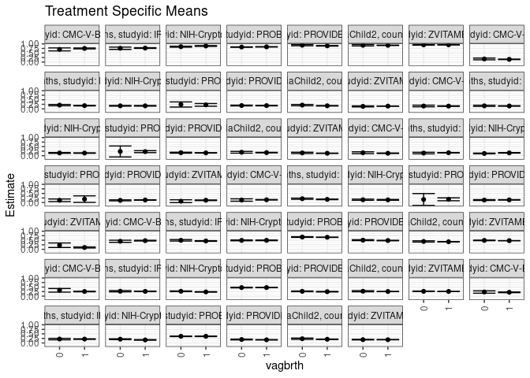

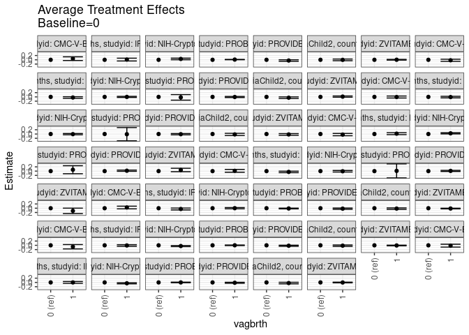

[figure not shown]

## Results Table

### Parameter: TSM

| agecat | studyid | country | intervention_level | baseline_level | estimate | ci_lower | ci_upper |
| --- | --- | --- | --- | --- | --- | --- | --- |
| 0-3 months | CMC-V-BCS-2002 | INDIA | 0 | NA | 0.6967204 | 0.6139620 | 0.7794788 |
| 0-3 months | CMC-V-BCS-2002 | INDIA | 1 | NA | 0.7504923 | 0.7258460 | 0.7751386 |
| 0-3 months | IRC | INDIA | 0 | NA | 0.7594520 | 0.6967586 | 0.8221454 |
| 0-3 months | IRC | INDIA | 1 | NA | 0.7697087 | 0.7500601 | 0.7893573 |
| 0-3 months | NIH-Crypto | BANGLADESH | 0 | NA | 0.8460417 | 0.8184754 | 0.8736080 |
| 0-3 months | NIH-Crypto | BANGLADESH | 1 | NA | 0.8861169 | 0.8615053 | 0.9107285 |
| 0-3 months | PROBIT | BELARUS | 0 | NA | 0.8260393 | 0.8160093 | 0.8360692 |
| 0-3 months | PROBIT | BELARUS | 1 | NA | 0.8368549 | 0.8257147 | 0.8479951 |
| 0-3 months | PROVIDE | BANGLADESH | 0 | NA | 0.9278173 | 0.8956272 | 0.9600074 |
| 0-3 months | PROVIDE | BANGLADESH | 1 | NA | 0.8937055 | 0.8772015 | 0.9102096 |
| 0-3 months | TanzaniaChild2 | TANZANIA, UNITED REPUBLIC OF | 0 | NA | 0.9248109 | 0.8871426 | 0.9624791 |
| 0-3 months | TanzaniaChild2 | TANZANIA, UNITED REPUBLIC OF | 1 | NA | 0.9217936 | 0.9113287 | 0.9322585 |
| 0-3 months | ZVITAMBO | ZIMBABWE | 0 | NA | 0.9468264 | 0.9299575 | 0.9636953 |
| 0-3 months | ZVITAMBO | ZIMBABWE | 1 | NA | 0.9498845 | 0.9444755 | 0.9552934 |
| 3-6 months | CMC-V-BCS-2002 | INDIA | 0 | NA | 0.4433967 | 0.3843515 | 0.5024419 |
| 3-6 months | CMC-V-BCS-2002 | INDIA | 1 | NA | 0.4773725 | 0.4575885 | 0.4971564 |
| 3-6 months | IRC | INDIA | 0 | NA | 0.4960738 | 0.4561598 | 0.5359878 |
| 3-6 months | IRC | INDIA | 1 | NA | 0.4601253 | 0.4406829 | 0.4795678 |
| 3-6 months | NIH-Crypto | BANGLADESH | 0 | NA | 0.4932105 | 0.4716751 | 0.5147460 |
| 3-6 months | NIH-Crypto | BANGLADESH | 1 | NA | 0.4946545 | 0.4767700 | 0.5125389 |
| 3-6 months | PROBIT | BELARUS | 0 | NA | 0.6763229 | 0.6581889 | 0.6944569 |
| 3-6 months | PROBIT | BELARUS | 1 | NA | 0.6642631 | 0.6560085 | 0.6725178 |
| 3-6 months | PROVIDE | BANGLADESH | 0 | NA | 0.5047004 | 0.4795079 | 0.5298929 |
| 3-6 months | PROVIDE | BANGLADESH | 1 | NA | 0.4843558 | 0.4691843 | 0.4995273 |
| 3-6 months | TanzaniaChild2 | TANZANIA, UNITED REPUBLIC OF | 0 | NA | 0.4347369 | 0.4012160 | 0.4682577 |
| 3-6 months | TanzaniaChild2 | TANZANIA, UNITED REPUBLIC OF | 1 | NA | 0.4174119 | 0.4084657 | 0.4263581 |
| 3-6 months | ZVITAMBO | ZIMBABWE | 0 | NA | 0.4918481 | 0.4759743 | 0.5077219 |
| 3-6 months | ZVITAMBO | ZIMBABWE | 1 | NA | 0.4770704 | 0.4723271 | 0.4818136 |
| 6-9 months | CMC-V-BCS-2002 | INDIA | 0 | NA | 0.3214219 | 0.2211207 | 0.4217231 |
| 6-9 months | CMC-V-BCS-2002 | INDIA | 1 | NA | 0.2550994 | 0.2395825 | 0.2706163 |

[output cut: 78 more lines]

### Parameter: E(Y)

| agecat | studyid | country | intervention_level | baseline_level | estimate | ci_lower | ci_upper |
| --- | --- | --- | --- | --- | --- | --- | --- |
| 0-3 months | CMC-V-BCS-2002 | INDIA | NA | NA | 0.7467559 | 0.7230662 | 0.7704455 |
| 0-3 months | IRC | INDIA | NA | NA | 0.7679906 | 0.7485485 | 0.7874326 |
| 0-3 months | NIH-Crypto | BANGLADESH | NA | NA | 0.8695604 | 0.8510808 | 0.8880400 |
| 0-3 months | PROBIT | BELARUS | NA | NA | 0.8356412 | 0.8250517 | 0.8462307 |
| 0-3 months | PROVIDE | BANGLADESH | NA | NA | 0.9016472 | 0.8868914 | 0.9164029 |
| 0-3 months | TanzaniaChild2 | TANZANIA, UNITED REPUBLIC OF | NA | NA | 0.9220792 | 0.9119561 | 0.9322023 |
| 0-3 months | ZVITAMBO | ZIMBABWE | NA | NA | 0.9496190 | 0.9444671 | 0.9547709 |
| 3-6 months | CMC-V-BCS-2002 | INDIA | NA | NA | 0.4751567 | 0.4562440 | 0.4940693 |
| 3-6 months | IRC | INDIA | NA | NA | 0.4660717 | 0.4485044 | 0.4836390 |
| 3-6 months | NIH-Crypto | BANGLADESH | NA | NA | 0.4940627 | 0.4803039 | 0.5078216 |
| 3-6 months | PROBIT | BELARUS | NA | NA | 0.6655962 | 0.6576122 | 0.6735801 |
| 3-6 months | PROVIDE | BANGLADESH | NA | NA | 0.4890611 | 0.4760060 | 0.5021163 |
| 3-6 months | TanzaniaChild2 | TANZANIA, UNITED REPUBLIC OF | NA | NA | 0.4190760 | 0.4103682 | 0.4277837 |
| 3-6 months | ZVITAMBO | ZIMBABWE | NA | NA | 0.4783589 | 0.4738121 | 0.4829056 |
| 6-9 months | CMC-V-BCS-2002 | INDIA | NA | NA | 0.2595889 | 0.2435057 | 0.2756721 |
| 6-9 months | IRC | INDIA | NA | NA | 0.2626310 | 0.2487635 | 0.2764985 |
| 6-9 months | NIH-Crypto | BANGLADESH | NA | NA | 0.2467592 | 0.2340792 | 0.2594392 |
| 6-9 months | PROBIT | BELARUS | NA | NA | 0.4737281 | 0.4649839 | 0.4824723 |
| 6-9 months | PROVIDE | BANGLADESH | NA | NA | 0.2491653 | 0.2371134 | 0.2612172 |
| 6-9 months | TanzaniaChild2 | TANZANIA, UNITED REPUBLIC OF | NA | NA | 0.2562013 | 0.2472582 | 0.2651444 |
| 6-9 months | ZVITAMBO | ZIMBABWE | NA | NA | 0.2584189 | 0.2539042 | 0.2629336 |
| 9-12 months | CMC-V-BCS-2002 | INDIA | NA | NA | 0.2123308 | 0.1948351 | 0.2298265 |
| 9-12 months | IRC | INDIA | NA | NA | 0.2132244 | 0.1989917 | 0.2274571 |
| 9-12 months | NIH-Crypto | BANGLADESH | NA | NA | 0.1841099 | 0.1707043 | 0.1975155 |
| 9-12 months | PROBIT | BELARUS | NA | NA | 0.3666836 | 0.3521958 | 0.3811713 |
| 9-12 months | PROVIDE | BANGLADESH | NA | NA | 0.1775316 | 0.1681968 | 0.1868664 |
| 9-12 months | TanzaniaChild2 | TANZANIA, UNITED REPUBLIC OF | NA | NA | 0.2052722 | 0.1951535 | 0.2153909 |
| 9-12 months | ZVITAMBO | ZIMBABWE | NA | NA | 0.1797523 | 0.1752000 | 0.1843045 |
| 12-15 months | CMC-V-BCS-2002 | INDIA | NA | NA | 0.1504668 | 0.1366572 | 0.1642764 |
| 12-15 months | IRC | INDIA | NA | NA | 0.1821426 | 0.1693469 | 0.1949383 |
| 12-15 months | NIH-Crypto | BANGLADESH | NA | NA | 0.1677313 | 0.1551957 | 0.1802668 |
| 12-15 months | PROBIT | BELARUS | NA | NA | 0.2225230 | 0.1483776 | 0.2966684 |
| 12-15 months | PROVIDE | BANGLADESH | NA | NA | 0.1800324 | 0.1683272 | 0.1917375 |
| 12-15 months | TanzaniaChild2 | TANZANIA, UNITED REPUBLIC OF | NA | NA | 0.1732074 | 0.1618786 | 0.1845362 |
| 12-15 months | ZVITAMBO | ZIMBABWE | NA | NA | 0.1500290 | 0.1420829 | 0.1579751 |
| 15-18 months | CMC-V-BCS-2002 | INDIA | NA | NA | 0.1521835 | 0.1380291 | 0.1663379 |
| 15-18 months | IRC | INDIA | NA | NA | 0.1604586 | 0.1468913 | 0.1740260 |
| 15-18 months | NIH-Crypto | BANGLADESH | NA | NA | 0.1467031 | 0.1332390 | 0.1601672 |
| 15-18 months | PROBIT | BELARUS | NA | NA | 0.2243786 | 0.1636115 | 0.2851457 |
| 15-18 months | PROVIDE | BANGLADESH | NA | NA | 0.1563514 | 0.1445823 | 0.1681205 |
| 15-18 months | TanzaniaChild2 | TANZANIA, UNITED REPUBLIC OF | NA | NA | 0.1702971 | 0.1559960 | 0.1845983 |
| 15-18 months | ZVITAMBO | ZIMBABWE | NA | NA | 0.1343108 | 0.1236882 | 0.1449334 |
| 18-21 months | CMC-V-BCS-2002 | INDIA | NA | NA | 0.1352327 | 0.1200477 | 0.1504178 |
| 18-21 months | IRC | INDIA | NA | NA | 0.1589791 | 0.1455977 | 0.1723606 |
| 18-21 months | NIH-Crypto | BANGLADESH | NA | NA | 0.1413896 | 0.1279457 | 0.1548336 |
| 18-21 months | PROBIT | BELARUS | NA | NA | 0.1781603 | 0.0230043 | 0.3333163 |
| 18-21 months | PROVIDE | BANGLADESH | NA | NA | 0.1324882 | 0.1210438 | 0.1439326 |
| 18-21 months | ZVITAMBO | ZIMBABWE | NA | NA | 0.1202513 | 0.1030776 | 0.1374250 |
| 21-24 months | CMC-V-BCS-2002 | INDIA | NA | NA | 0.1484491 | 0.1344875 | 0.1624106 |
| 21-24 months | IRC | INDIA | NA | NA | 0.1777340 | 0.1639174 | 0.1915507 |
| 21-24 months | NIH-Crypto | BANGLADESH | NA | NA | 0.1473540 | 0.1301532 | 0.1645548 |
| 21-24 months | PROBIT | BELARUS | NA | NA | 0.1751208 | 0.0912401 | 0.2590016 |
| 21-24 months | PROVIDE | BANGLADESH | NA | NA | 0.1419705 | 0.1305335 | 0.1534075 |
| 21-24 months | ZVITAMBO | ZIMBABWE | NA | NA | 0.1095404 | 0.0813931 | 0.1376877 |

### Parameter: ATE

| agecat | studyid | country | intervention_level | baseline_level | estimate | ci_lower | ci_upper |
| --- | --- | --- | --- | --- | --- | --- | --- |
| 0-3 months | CMC-V-BCS-2002 | INDIA | 0 | 0 | 0.0000000 | 0.0000000 | 0.0000000 |
| 0-3 months | CMC-V-BCS-2002 | INDIA | 1 | 0 | 0.0537719 | -0.0325785 | 0.1401223 |
| 0-3 months | IRC | INDIA | 0 | 0 | 0.0000000 | 0.0000000 | 0.0000000 |
| 0-3 months | IRC | INDIA | 1 | 0 | 0.0102567 | -0.0554436 | 0.0759570 |
| 0-3 months | NIH-Crypto | BANGLADESH | 0 | 0 | 0.0000000 | 0.0000000 | 0.0000000 |
| 0-3 months | NIH-Crypto | BANGLADESH | 1 | 0 | 0.0400752 | 0.0031207 | 0.0770296 |
| 0-3 months | PROBIT | BELARUS | 0 | 0 | 0.0000000 | 0.0000000 | 0.0000000 |
| 0-3 months | PROBIT | BELARUS | 1 | 0 | 0.0108156 | 0.0017383 | 0.0198929 |
| 0-3 months | PROVIDE | BANGLADESH | 0 | 0 | 0.0000000 | 0.0000000 | 0.0000000 |
| 0-3 months | PROVIDE | BANGLADESH | 1 | 0 | -0.0341118 | -0.0702862 | 0.0020626 |
| 0-3 months | TanzaniaChild2 | TANZANIA, UNITED REPUBLIC OF | 0 | 0 | 0.0000000 | 0.0000000 | 0.0000000 |
| 0-3 months | TanzaniaChild2 | TANZANIA, UNITED REPUBLIC OF | 1 | 0 | -0.0030173 | -0.0421122 | 0.0360777 |
| 0-3 months | ZVITAMBO | ZIMBABWE | 0 | 0 | 0.0000000 | 0.0000000 | 0.0000000 |
| 0-3 months | ZVITAMBO | ZIMBABWE | 1 | 0 | 0.0030580 | -0.0146568 | 0.0207729 |
| 3-6 months | CMC-V-BCS-2002 | INDIA | 0 | 0 | 0.0000000 | 0.0000000 | 0.0000000 |
| 3-6 months | CMC-V-BCS-2002 | INDIA | 1 | 0 | 0.0339758 | -0.0282957 | 0.0962473 |
| 3-6 months | IRC | INDIA | 0 | 0 | 0.0000000 | 0.0000000 | 0.0000000 |
| 3-6 months | IRC | INDIA | 1 | 0 | -0.0359485 | -0.0803460 | 0.0084490 |
| 3-6 months | NIH-Crypto | BANGLADESH | 0 | 0 | 0.0000000 | 0.0000000 | 0.0000000 |
| 3-6 months | NIH-Crypto | BANGLADESH | 1 | 0 | 0.0014439 | -0.0265494 | 0.0294373 |
| 3-6 months | PROBIT | BELARUS | 0 | 0 | 0.0000000 | 0.0000000 | 0.0000000 |
| 3-6 months | PROBIT | BELARUS | 1 | 0 | -0.0120597 | -0.0304572 | 0.0063378 |
| 3-6 months | PROVIDE | BANGLADESH | 0 | 0 | 0.0000000 | 0.0000000 | 0.0000000 |
| 3-6 months | PROVIDE | BANGLADESH | 1 | 0 | -0.0203447 | -0.0497528 | 0.0090635 |
| 3-6 months | TanzaniaChild2 | TANZANIA, UNITED REPUBLIC OF | 0 | 0 | 0.0000000 | 0.0000000 | 0.0000000 |
| 3-6 months | TanzaniaChild2 | TANZANIA, UNITED REPUBLIC OF | 1 | 0 | -0.0173249 | -0.0520190 | 0.0173692 |
| 3-6 months | ZVITAMBO | ZIMBABWE | 0 | 0 | 0.0000000 | 0.0000000 | 0.0000000 |
| 3-6 months | ZVITAMBO | ZIMBABWE | 1 | 0 | -0.0147778 | -0.0313451 | 0.0017895 |
| 6-9 months | CMC-V-BCS-2002 | INDIA | 0 | 0 | 0.0000000 | 0.0000000 | 0.0000000 |
| 6-9 months | CMC-V-BCS-2002 | INDIA | 1 | 0 | -0.0663225 | -0.1678169 | 0.0351719 |

[output cut: 78 more lines]

### Parameter: PAR

| agecat | studyid | country | intervention_level | baseline_level | estimate | ci_lower | ci_upper |
| --- | --- | --- | --- | --- | --- | --- | --- |
| 0-3 months | CMC-V-BCS-2002 | INDIA | 0 | NA | 0.0500355 | -0.0303282 | 0.1303993 |
| 0-3 months | IRC | INDIA | 0 | NA | 0.0085385 | -0.0461574 | 0.0632345 |
| 0-3 months | NIH-Crypto | BANGLADESH | 0 | NA | 0.0235187 | 0.0017584 | 0.0452791 |
| 0-3 months | PROBIT | BELARUS | 0 | NA | 0.0096019 | 0.0015567 | 0.0176471 |
| 0-3 months | PROVIDE | BANGLADESH | 0 | NA | -0.0261701 | -0.0539452 | 0.0016049 |
| 0-3 months | TanzaniaChild2 | TANZANIA, UNITED REPUBLIC OF | 0 | NA | -0.0027317 | -0.0381266 | 0.0326632 |
| 0-3 months | ZVITAMBO | ZIMBABWE | 0 | NA | 0.0027926 | -0.0133845 | 0.0189697 |
| 3-6 months | CMC-V-BCS-2002 | INDIA | 0 | NA | 0.0317600 | -0.0264576 | 0.0899775 |
| 3-6 months | IRC | INDIA | 0 | NA | -0.0300021 | -0.0670789 | 0.0070747 |
| 3-6 months | NIH-Crypto | BANGLADESH | 0 | NA | 0.0008522 | -0.0156696 | 0.0173740 |
| 3-6 months | PROBIT | BELARUS | 0 | NA | -0.0107267 | -0.0270167 | 0.0055633 |
| 3-6 months | PROVIDE | BANGLADESH | 0 | NA | -0.0156393 | -0.0382563 | 0.0069777 |
| 3-6 months | TanzaniaChild2 | TANZANIA, UNITED REPUBLIC OF | 0 | NA | -0.0156609 | -0.0470236 | 0.0157018 |
| 3-6 months | ZVITAMBO | ZIMBABWE | 0 | NA | -0.0134893 | -0.0286124 | 0.0016339 |
| 6-9 months | CMC-V-BCS-2002 | INDIA | 0 | NA | -0.0618330 | -0.1564743 | 0.0328084 |
| 6-9 months | IRC | INDIA | 0 | NA | -0.0060665 | -0.0367189 | 0.0245859 |
| 6-9 months | NIH-Crypto | BANGLADESH | 0 | NA | -0.0199867 | -0.0352842 | -0.0046891 |
| 6-9 months | PROBIT | BELARUS | 0 | NA | 0.0014847 | -0.0113736 | 0.0143431 |
| 6-9 months | PROVIDE | BANGLADESH | 0 | NA | -0.0148373 | -0.0342539 | 0.0045793 |
| 6-9 months | TanzaniaChild2 | TANZANIA, UNITED REPUBLIC OF | 0 | NA | -0.0142944 | -0.0438283 | 0.0152395 |
| 6-9 months | ZVITAMBO | ZIMBABWE | 0 | NA | -0.0065934 | -0.0213786 | 0.0081919 |
| 9-12 months | CMC-V-BCS-2002 | INDIA | 0 | NA | -0.0146781 | -0.0771226 | 0.0477664 |
| 9-12 months | IRC | INDIA | 0 | NA | -0.0002475 | -0.0355822 | 0.0350871 |
| 9-12 months | NIH-Crypto | BANGLADESH | 0 | NA | -0.0229967 | -0.0388903 | -0.0071031 |
| 9-12 months | PROBIT | BELARUS | 0 | NA | -0.0002826 | -0.0126522 | 0.0120871 |
| 9-12 months | PROVIDE | BANGLADESH | 0 | NA | -0.0120255 | -0.0299734 | 0.0059224 |
| 9-12 months | TanzaniaChild2 | TANZANIA, UNITED REPUBLIC OF | 0 | NA | -0.0268771 | -0.0599000 | 0.0061457 |
| 9-12 months | ZVITAMBO | ZIMBABWE | 0 | NA | -0.0026089 | -0.0175771 | 0.0123592 |
| 12-15 months | CMC-V-BCS-2002 | INDIA | 0 | NA | -0.0204008 | -0.0672788 | 0.0264772 |
| 12-15 months | IRC | INDIA | 0 | NA | -0.0235474 | -0.0550532 | 0.0079584 |
| 12-15 months | NIH-Crypto | BANGLADESH | 0 | NA | 0.0001194 | -0.0147767 | 0.0150156 |
| 12-15 months | PROBIT | BELARUS | 0 | NA | -0.0189885 | -0.1309181 | 0.0929411 |
| 12-15 months | PROVIDE | BANGLADESH | 0 | NA | -0.0029952 | -0.0228170 | 0.0168266 |
| 12-15 months | TanzaniaChild2 | TANZANIA, UNITED REPUBLIC OF | 0 | NA | -0.0337824 | -0.0686451 | 0.0010804 |
| 12-15 months | ZVITAMBO | ZIMBABWE | 0 | NA | 0.0133061 | -0.0138729 | 0.0404851 |
| 15-18 months | CMC-V-BCS-2002 | INDIA | 0 | NA | -0.0048455 | -0.0482498 | 0.0385589 |
| 15-18 months | IRC | INDIA | 0 | NA | -0.0063289 | -0.0363328 | 0.0236749 |
| 15-18 months | NIH-Crypto | BANGLADESH | 0 | NA | -0.0040445 | -0.0217387 | 0.0136497 |
| 15-18 months | PROBIT | BELARUS | 0 | NA | -0.0082756 | -0.2762961 | 0.2597449 |
| 15-18 months | PROVIDE | BANGLADESH | 0 | NA | -0.0069627 | -0.0293982 | 0.0154728 |
| 15-18 months | TanzaniaChild2 | TANZANIA, UNITED REPUBLIC OF | 0 | NA | -0.0173175 | -0.0637980 | 0.0291630 |
| 15-18 months | ZVITAMBO | ZIMBABWE | 0 | NA | -0.0188427 | -0.0547195 | 0.0170340 |
| 18-21 months | CMC-V-BCS-2002 | INDIA | 0 | NA | -0.0252385 | -0.0753178 | 0.0248408 |
| 18-21 months | IRC | INDIA | 0 | NA | 0.0142651 | -0.0234506 | 0.0519808 |
| 18-21 months | NIH-Crypto | BANGLADESH | 0 | NA | 0.0193023 | 0.0029292 | 0.0356755 |
| 18-21 months | PROBIT | BELARUS | 0 | NA | 0.0560111 | -0.1075854 | 0.2196076 |
| 18-21 months | PROVIDE | BANGLADESH | 0 | NA | 0.0148324 | -0.0079994 | 0.0376641 |
| 18-21 months | ZVITAMBO | ZIMBABWE | 0 | NA | 0.0494497 | -0.0251289 | 0.1240284 |
| 21-24 months | CMC-V-BCS-2002 | INDIA | 0 | NA | 0.0128367 | -0.0486189 | 0.0742922 |
| 21-24 months | IRC | INDIA | 0 | NA | -0.0308200 | -0.0606659 | -0.0009741 |
| 21-24 months | NIH-Crypto | BANGLADESH | 0 | NA | -0.0041797 | -0.0266519 | 0.0182925 |
| 21-24 months | PROBIT | BELARUS | 0 | NA | 0.0090961 | -0.2768575 | 0.2950498 |
| 21-24 months | PROVIDE | BANGLADESH | 0 | NA | 0.0075407 | -0.0123669 | 0.0274483 |
| 21-24 months | ZVITAMBO | ZIMBABWE | 0 | NA | -0.1147166 | -0.2329802 | 0.0035469 |